# Practical Machine Learning Course Project

Ed Rogers

October 21, 2015

# Executive Summary

Various models are fit on the Human Activity Recognition training dataset provided. After comparison, a Random Forest model is selected, tuned, and trained on the dataset in order to predict the missing `classe` variable in the test dataset provided.

# Exploratory Data Analysis

Data are loaded from downloaded files, and a brief exploratory analysis shows a majority of the rows in the original training data can be dropped.

```r
library(GGally)
library(caret)
library(nnet)
library(doParallel)
library(dplyr)

registerDoParallel(cores = 4)

set.seed(1234)
setwd("~/R/MachineLearning/CourseProject/")

train <- read.csv("pml-training.csv")
test  <- read.csv("pml-testing.csv")

#Many rows of the Test dataset are not useful, as they have all NA values.
sum(colSums(is.na(test)) == nrow(test))
```

```
## [1] 100
```

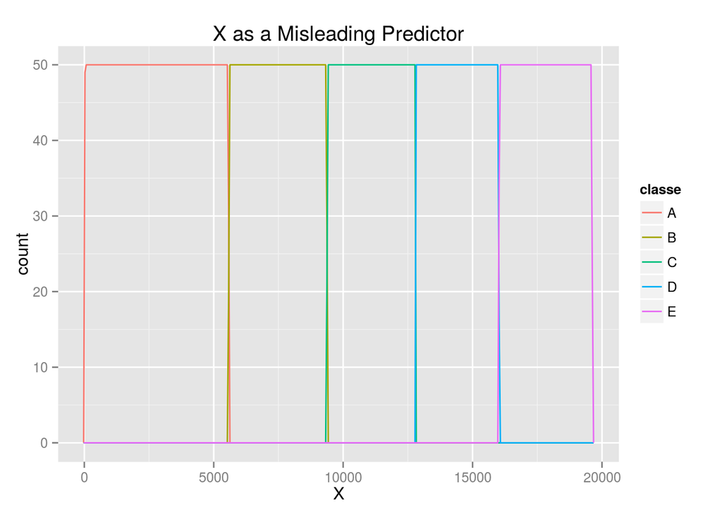

```r
#These rows can be dropped safely from both the Test and Train datasets.
test <- test[,colSums(is.na(test)) != nrow(test)]
usefulColumns <- colnames(test)
usefulColumns <- c(usefulColumns,"classe")
train <- train[,which(colnames(train) %in% usefulColumns)]

#The variable "X" has a perfect correlation with the "classe" value in the training dataset. This could mislead our model, so we will exclude it from training.
ggplot(train, aes(X)) +
  geom_freqpoly(aes(group = classe, colour = classe),binwidth=50) +
  ggtitle("X as a Misleading Predictor")
```

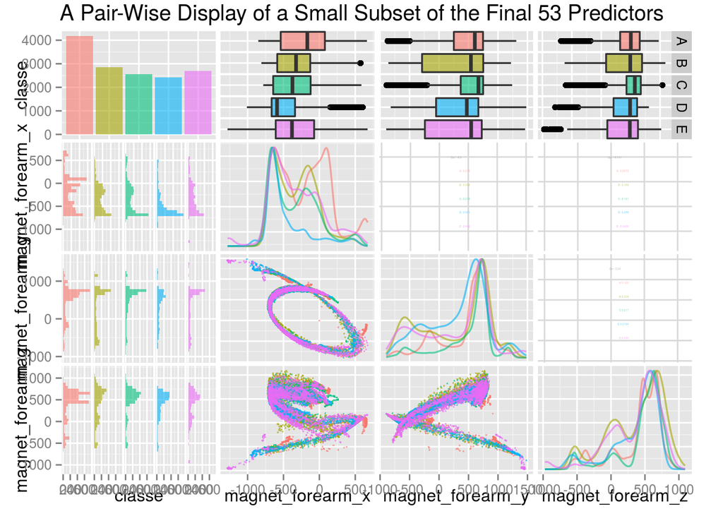

```r
train <- train[,-grep("^X$",colnames(train))]
test  <- test[,-grep("^X$",colnames(test))]

#Also removing "timestamp" and "window" vars
train <- train[,-grep("timestamp",colnames(train))]
test  <- test[,-grep("timestamp",colnames(test))]
train <- train[,-grep("window",colnames(train))]
test  <- test[,-grep("window",colnames(test))]

#Some data should be reserved for out-of-sample error estimation
inTrain <- createDataPartition(y=train$classe,p=0.75,list=FALSE)
fullTrainingData     <- train
trainErrorEstimation <- train[-inTrain,]
train                <- train[inTrain,]

#Some EDA on variable subsets:
ggpairs(data=train,
        columns = c(grep("classe",colnames(train)),51:53),
        color="classe",
        title="A Pair-Wise Display of a Small Subset of the Final 53 Predictors",
        params=c(alpha=6/10,size=6/10))
```

**Figure 2:** After an exploratory data analysis, 53 of the predictor variables and 1 response variable are retained for our model creation. Looking at a small subset of these predictors, we can see they have complicated relationships that may lend themselves to a machine learning approach.

# Model Comparison

Multiple models will be trained and tuned on the `train` data.frame. The `trainErrorEstimation` data.frame will be held in reserve for a final, out-of-sample error estimate after a final model is selected.

## RPart

```r
confusionMatrixError <- function(CM) {
  (sum(CM[1:5,1:5])-sum(diag(CM)))/sum(CM[1:5,1:5])
}

minimumErrors <- data.frame()

modFitRPart <- train(classe ~ ., data=train, method="rpart")
CMRPart <- confusionMatrix(train$classe,predict(modFitRPart,train))$table
#OOB estimate of  error rate:
minimumErrors <- rbind(minimumErrors,rpart=c(confusionMatrixError(CMRPart)))
colnames(minimumErrors) <- "minErr"
```

## Linear Discriminant Analysis

```r
modFitLDA <- train(classe ~ ., data=train, method="lda")
CMLDA <- confusionMatrix(train$classe,predict(modFitLDA,train))$table
#OOB estimate of  error rate:
minimumErrors <- rbind(minimumErrors,lda=c(confusionMatrixError(CMLDA)))
```

## Naive Bayes

```r
modFitNB <- train(classe ~ ., data=train, method="nb")
CMNB <- confusionMatrix(train$classe,predict(modFitNB,train))$table
#OOB estimate of  error rate:
minimumErrors <- rbind(minimumErrors,nb=c(confusionMatrixError(CMNB)))
```

## Multinomial

```r
modFitMN <- multinom(classe ~ ., data=train,maxit=1000)
CMMN <- confusionMatrix(train$classe,predict(modFitMN,train))$table
#OOB estimate of  error rate:
minimumErrors <- rbind(minimumErrors,mn=c(confusionMatrixError(CMMN)))
```

## Random Forest

```r
modFitRF   <- train(classe ~ ., data=train, method="rf")
#modFitRF   <- randomForest(classe ~ ., data=train)
CMRF <- confusionMatrix(modFitRF)$table
#OOB estimate of  error rate:
minimumErrors <- rbind(minimumErrors,rf=c(confusionMatrixError(CMRF)))
```

# Final Model Selection:

First, we can roughly compare the models by considering their Minimum Error Rate, as computed using each model on the original `train` dataset to create a Confusion Matrix. This value should underestimate the error due to over-fitting, but is nevertheless a worthwhile comparison between different models.

```r
minimumErrors <- minimumErrors[order(minimumErrors$minErr),,drop=FALSE]
minimumErrors
```

```
##           minErr
## rf    0.01029308
## mn    0.22000272
## nb    0.25078136
## lda   0.26416633
## rpart 0.50455225
```

```r
minimumErrors <- minimumErrors[1,,drop=FALSE]
```

It is evident that Random Forests is the superior modeling technique for this problem.

From this point forward, we switch to using the `randomForests` library, as it is much more efficient for performing these computations.

## Tuning Random Forests

### Tuning the mtry Parameter

By tuning the mtry parameter, modest gains can be made in reducing the minimum error rate. We’ve started with an mtry of 29, which we will tune for lowest Out-Of-Bag Error, and retrain.

```
## mtry = 29  OOB error = 0.84%
## Searching left ...
## mtry = 20    OOB error = 0.74%
## 0.1138211 0.001
## mtry = 14    OOB error = 0.75%
## -0.009174312 0.001
## Searching right ...
## mtry = 43    OOB error = 1.09%
## -0.4770642 0.001
```

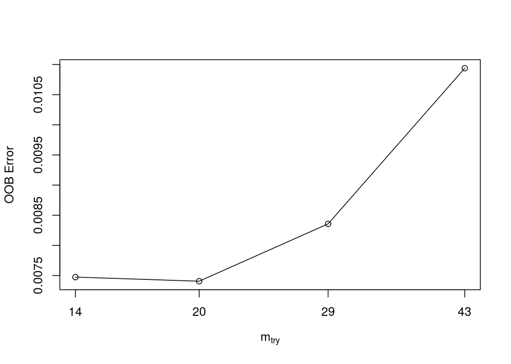

```r
library(randomForest)
modFitTuned <- tuneRF(train[,-54],train[,54],
                      mtryStart = modFitRF$finalModel$mtry,
                      stepFactor=1.5,
                      improve = 0.001,
                      plot=TRUE,
                      doBest = TRUE)
```

**Figure 3:** After tuning, the best `mtry` value, 20, was selected for the final model for its low Out-Of-Bag Error.

```r
#OOB estimate of  error rate:
minimumErrors <- rbind(minimumErrors,rfTuned=c(confusionMatrixError(modFitTuned$confusion)))
```

# Computing the Out-Of-Sample Error for the Final Model

The model can now be applied to the reserved data to estimate its out-of-sample error.

```r
oosPredict <- predict(modFitTuned,trainErrorEstimation)
CMOutOfSample <- confusionMatrix(trainErrorEstimation$classe,oosPredict)$table
#OOB estimate of  error rate:
minimumErrors <- rbind(minimumErrors,OutOfSample=c(confusionMatrixError(CMOutOfSample)))
minimumErrors
```

```
##                  minErr
## rf          0.010293076
## rfTuned     0.005299633
## OutOfSample 0.004282219
```

```r
OutOfSampleError <- paste(round(100*confusionMatrixError(CMOutOfSample),digits = 2),"%",sep="")
OutOfSampleError
```

```
## [1] "0.43%"
```

## The Out-Of-Sample Error using Cross-Validation is 0.43%

Using cross-validation, the most accurate prediction of Out-Of-Sample error rate using this particular tuning of Random Forests is 0.43%. We will now retrain one last time, using all of the training data to prepare for our test sample.

```r
modFitFinal <- randomForest(classe ~ ., data=fullTrainingData,
                            mtry=modFitTuned$mtry)
```

# Predicting the Test Set

Using the fully-tuned, fully-trained model, the test set can be predicted.

```r
testPredictions <- predict(modFitFinal,test)
testPredictions
```

```
##  1  2  3  4  5  6  7  8  9 10 11 12 13 14 15 16 17 18 19 20
##  B  A  B  A  A  E  D  B  A  A  B  C  B  A  E  E  A  B  B  B
## Levels: A B C D E
```

Last, the submissions files are generated using the code provided by the Coursera instructions.

```r
pml_write_files = function(x){
  n = length(x)
  for(i in 1:n){
    filename = paste0("problem_id_",i,".txt")
    write.table(x[i],file=filename,quote=FALSE,row.names=FALSE,col.names=FALSE)
  }
}

pml_write_files(testPredictions)
```